# Sumário

```python
import pandas as pd
import numpy as np
from scipy import stats
import seaborn as sns
import matplotlib.pyplot as plt
from decimal import Decimal

import warnings
warnings.filterwarnings('ignore')
```

```python
df_salarios = pd.read_csv('dados/dados_tratados.csv').drop('Unnamed: 0', axis=1)
df_b3 = pd.read_csv('dados/b3_stocks_1994_2020.csv')
df_b3['datetime'] = pd.to_datetime(df_b3['datetime'])
```

# Conceito

Vamos a um exemplo para ficar fácil a compreensão. Vamos criar uma tabela de contingência de `tamanho da companhia` por `tipo de trabalho`.

```python
dcf = pd.crosstab(df_salarios['tamanho_companhia'], df_salarios['tipo_trabalho'])
dcf_total = dcf.copy()
dcf_total['Total'] = dcf.sum(axis=1, numeric_only=True)
dcf2 = pd.DataFrame({dcf_total.columns[0]: dcf_total['Hibrido'].sum(),
                     dcf_total.columns[1]: dcf_total['Home office'].sum(),
                     dcf_total.columns[2]: dcf_total['Presencial'].sum(),
                     dcf_total.columns[3]: dcf_total['Total'].sum()}, index=['Total'])
dcf_total = dcf_total.append(dcf2)
dcf_total
```

|  | Hibrido | Home office | Presencial | Total |
| --- | --- | --- | --- | --- |
| Grande | 110 | 220 | 124 | 454 |
| Medio | 47 | 1332 | 1774 | 3153 |
| Pequeno | 32 | 91 | 25 | 148 |
| Total | 189 | 1643 | 1923 | 3755 |

Digamos que um profissional está vendo opções para um novo emprego e esse profissional está fazendo isso por um critério de pontos. Esses pontos seguem uma lógica:

- Tamanho da empresa:
  - Grande: 3 pontos
  - Média: 2 pontos
  - Pequena: 1 ponto
- Tipo de trabalho:
  - Home office: 3 pontos
  - Hibrido: 2 pontos
  - Presencial: 1 ponto

Também sabemos o percentual de cada empresa e tipo de trabalho baseado na pesquisa.

- Tamanho da empresa:
  - Grande: 12%
  - Média: 84%
  - Pequena: 4%
- Tipo de trabalho:
  - Home office: 44%
  - Hibrido: 5%
  - Presencial: 51%

Logo nós podemos ter as seguintes combinações:

| Combinação | Probabilidade | Pontos |
| --- | --- | --- |
| Grande - Home office | 0,0528 | 6 |
| Grande - Híbrido | 0,006 | 5 |
| Grande - Presencial | 0,0612 | 4 |
| Media - Home office | 0,3696 | 5 |
| Media - Híbrido | 0,042 | 4 |
| Media - Presencial | 0,4284 | 3 |
| Pequena - Home office | 0,0176 | 4 |
| Pequena - Híbrido | 0,002 | 3 |
| Pequena - Presencial | 0,0204 | 2 |

Com isso, podemos presumir que:

Cada um desses eventos tem uma probabilidade associada

- $P(A_1) = 0,0528$
- $P(A_2) = 0,3756$
- $P(A_3) = 0,1208$
- $P(A_4) = 0,4304$
- $P(A_5) = 0,0204$

com esses valores nós somos capazes de escrever a função $(x, p(x))$, que é um modelo teórico para a distribuição da variável X, que o profissional poderá usar para julgar a viabilidade de ir trabalhar em uma empresa.

| x | $p(x)$ |
| --- | --- |
| 6 | 0,0528 |
| 5 | 0,3756 |
| 4 | 0,1208 |
| 3 | 0,4304 |
| 2 | 0,0204 |

**Definição**:

Uma variável aleatória discreta ($X$) é uma função que atribui valores numéricos enumeráveis aos resultados de um experimento. Toda variável aleatória discreta tem uma probabilidade atribuída. Essa probabilidade chamamos de **função massa de probabilidade** por:

$$p(x_i) = P(X = x_i) = p_i$$

Onde:

- i = 1, 2, 3...

Voltando ao nosso exemplo pra simplificar esses termos. Temos o evento $A_1$ que é a combinação de `Empresa Grande - Home office`. Esse evento atribuímos um valor numérico $x_1$ que é igual a 6. A partir disso calculamos a probabilidade desse evento ocorrer. Logo:

$$p(x_1) = P(X = x_1) = 0,0528$$

Isso nos mostra que quando nossa variável aleatória discreta for 6, temos essa probabilidade.

# Valor médio de uma Variável Aleatória (Esperança matemática)

Pegando nosso exemplo anterior, qual será a pontuação média das empresas que o profissional espera conseguir?

Dá tabela de distribuição que criamos, temos que:

| x | $p(x)$ |
| --- | --- |
| 6 | 0,0528 |
| 5 | 0,3756 |
| 4 | 0,1208 |
| 3 | 0,4304 |
| 2 | 0,0204 |

Logo, a pontuação esperada para as empresas é:

$$\text{pontuação média} = (6 \cdot 0,0528) + (5 \cdot 0,3756) + (4 \cdot 0,1208) + (3 \cdot 0,4304) + (2 \cdot 0,0204) = 4,01$$

Isso significa que, dado que as suposições feitas para determinar a distribuição da variável aleatória sejam verdadeiras, o profissional espera que as empresas tenham 4,01 pontos.

Formalizando, temos:

A esperança matemática ou valor médio de X é dado por:

$$E(X) = \sum_{i=1}^{n}x_i \cdot P(X = x_i) = \sum_{i=1}^{n}x_i \cdot p_i$$

Com o valor da esperança matemática, somos capazes de achar o valor da variância da variável aleatória:

$$\text{Var}(X) = \sum_{i=1}^{n}[x_i - E(X)]² \cdot p_i$$

Calculando para nosso caso:

$$\text{Var}(X) = ([6 - 4,01]² \cdot 0,0528) + ([5 - 4,01]² \cdot 0,3756) + ([4 - 4,01]² \cdot 0,1208) + ([3 - 4,01]² \cdot 0,4304) + ([2 - 4,01]² \cdot 0,0204) $$$$\text{Var}(X) = 0,21 + 0,37 + 0,000012 + 0,44 + 0,08 = 1,1$$

Como temos a variância, podemos achar o desvio padrão.

$$\text{DP}(X) = \sqrt{\text{Var}(X)} = \sqrt{\sum_{i=1}^{n}[x_i - E(X)]² \cdot p_i} $$

No nosso caso o desvio padrão é:

$$\text{DP}(X) = \sqrt{1,1} = 1,048$$

Vamos achar esses valores com Python.

```python
x = [2, 3, 4, 5, 6]
p_x = [0.0204, 0.4304, 0.1208, 0.3756, 0.0528]

df_esperanca = pd.DataFrame({'x': x, 'px': p_x})
df_esperanca
```

|  | x | px |
| --- | --- | --- |
| 0 | 2 | 0.0204 |
| 1 | 3 | 0.4304 |
| 2 | 4 | 0.1208 |
| 3 | 5 | 0.3756 |
| 4 | 6 | 0.0528 |

```python
def esperanca_matematica(df, x, px):
    return sum(df[x] * df[px])

esperanca_matematica(df_esperanca, 'x', 'px')
```

```
4.01
```

```python
def varianca_variavel_aleatoria(df, x, px):
    valor_medio = esperanca_matematica(df, x, px)
    return sum(((df[x] - valor_medio)**2) * df[px])

varianca_variavel_aleatoria(df_esperanca, 'x', 'px')
```

```
1.0987
```

```python
def desvio_padrao_variavel_aleatoria(df, x, px):
    variancia = varianca_variavel_aleatoria(df_esperanca, x, px)
    return np.sqrt(variancia)

desvio_padrao_variavel_aleatoria(df_esperanca, 'x', 'px')
```

```
1.0481889142707053
```

# Função de distribuição acumulada

Voltando no nosso exemplo temos:

| x | $p(x)$ |
| --- | --- |
| 6 | 0,0528 |
| 5 | 0,3756 |
| 4 | 0,1208 |
| 3 | 0,4304 |
| 2 | 0,0204 |

Logo, a função de distribuição acumulada de X será dada por:

$$F(x) = \begin{cases} 0, & \text{se x} < 2 \\ 0,0204, & \text{se 2} \leq x < 3 \\ 0,4508, & \text{se 3} \leq x < 4 \\ 0,5716, & \text{se 4} \leq x < 5 \\ 0,9472, & \text{se 5} \leq x < 6 \\ 1, & \text{se x} \geq 6\\ \end{cases}$$

Formalizando:

$$F(x) = P(X \leq x)$$

Com python temos:

```python
df_acumulado = df_esperanca.copy()
df_acumulado['fda'] = df_acumulado['px'].cumsum()
df_acumulado
```

|  | x | px | fda |
| --- | --- | --- | --- |
| 0 | 2 | 0.0204 | 0.0204 |
| 1 | 3 | 0.4304 | 0.4508 |
| 2 | 4 | 0.1208 | 0.5716 |
| 3 | 5 | 0.3756 | 0.9472 |
| 4 | 6 | 0.0528 | 1.0000 |

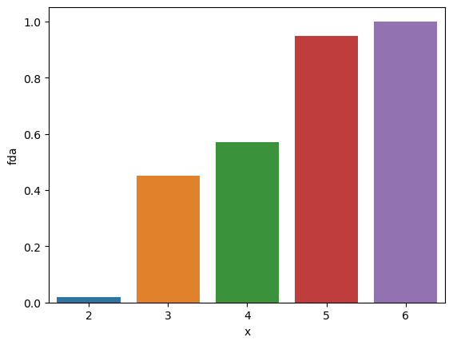

```python
sns.barplot(data=df_acumulado, x="x", y="fda")
```

# Distribuições discretas de probabilidade

## Distribuição uniforme discreta

Uma variável aleatória X é considerada uniforme se todos os valores tiveram os mesmos valores de probabilidade:

$$P(X = x_i) = p(x_i) = p = \frac{1}{k}$$

para todo $i = 1, 2, 3, ..., k$

**Exemplo**: Seja a variável aleatória X o número de pontos marcados na face de um dado quando o mesmo é lançado. Qual a probabilidade de cada lado aparecer?

Considerando o dado não viciado, temos que a probabilidade é:

$$P(X = x_1) = P(X = x_2) = P(X = x_3) = P(X = x_4) = P(X = x_5) = P(X = x_6) = \frac{1}{6}$$

Sua esperança é dada por:

$$E(X) = \sum_{i=1}^{n}x_i \cdot P(X = x_i) = \sum_{i=1}^{n}x_i \cdot p_i$$

Sabendo que $p_i$ é igual para todos os valores compreendidos, então

$$E(X) =\frac{1}{k} \cdot \sum_{i=1}^{n}x_i = \frac{\sum_{i=1}^{n}x_i}{k} $$

a variância é:

$$\text{Var}(X) = \frac{\sum_{i=1}^{n}[x_i - \frac{\sum_{i=1}^{n}x_i}{k}]²}{k}$$

e a função de distribuição acumulada é dada por:

$$F(X) = \sum_{x_i \leq x}\frac{1}{k} = \frac{n(x)}{k}$$

onde $n(x)$ é o número de $x_1 \leq x$.

```python
def distribuicao_uniforme(k):
    return 1/k

print(f'Cada um dos {6} resultados tem a probabilidade de {distribuicao_uniforme(6)} de ocorrer')
```

```
Cada um dos 6 resultados tem a probabilidade de 0.16666666666666666 de ocorrer
```

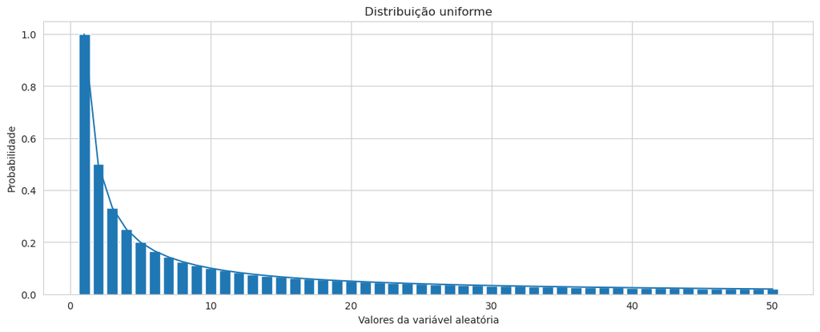

```python
# vendo como o aumento de valores muda a probabilidade
lista = []
lista2 = []
for i in range(1, 51):
    lista.append(distribuicao_uniforme(i))
    lista2.append(i)

with sns.axes_style("whitegrid"):
    plt.figure(figsize=(14, 5))
    plt.bar(lista2, lista)
    plt.plot(lista2, lista)
    plt.xlabel('Valores da variável aleatória')
    plt.ylabel('Probabilidade')
    plt.title('Distribuição uniforme')
    plt.show()
```

## Distribuição de Bernoulli

Nessa distribuição, a variável aleatória X assume apenas dois valores,chamados de `sucesso` e `fracasso`.

Vamos ver novamente nossa tabela de contingência.

```python
dcf
```

| tipo_trabalho tamanho_companhia | Hibrido | Home office | Presencial |
| --- | --- | --- | --- |
| Grande | 110 | 220 | 124 |
| Medio | 47 | 1332 | 1774 |
| Pequeno | 32 | 91 | 25 |

Nesse caso, vamos imaginar que escolhemos um funcionário ao acaso entre todos os funcionários listados e vamos verificar se essa funcionário trabalha no regime presencial. Nossa opções seriam:

- Trabalha no regime presencial (sucesso)
- Não trabalha no regime presencial (fracasso)

Logo para esse experimento acima, podemos definir uma variável aleatória X, que assume apenas dois valores:

- 1, se ocorrer sucesso
- 0, se ocorrer fracasso

Chamaremos de $p$ a probabilidade de sucesso, então temos:

$$p(0) = P(X = 0) = 1 - p$$$$p(1) = P(X = 1) = p$$

Nesse caso, temos 1923 funcionários que trabalham presencialmente, para um total de 3755

então:

$$p(1) = P(X = 1) = \frac{1923}{3755} = 0,51$$$$p(0) = P(X = 1) = 1 - 0,51 = 0,49$$

Temos 51% de probabilidade de ao acaso escolher um trabalhador que trabalhe no regime presencial, e 49% de não conseguir.

a esperança matemática é dada por:

$$E(X) = p$$

a variância:

$$\text{Var}(X) = p-p² = p\cdot(1 - p) $$

e a função de distribuição acumulada:

$$F(x) = \begin{cases} 0, & \text{se x} < 0 \\ 1 - p, & \text{se 0} \leq x < 1 \\ 1, & \text{se x} \geq 1\\ \end{cases}$$

Quando uma variável aleatória tiver a distribuição de Bernoulli, usaremos a seguinte notação:

$$X \sim Ber(p)$$

No Python, podemos escrever como:

```python
def distribuicao_bernoulli(p):
    sucesso = p
    fracasso = 1 - p
    return sucesso, fracasso

distribuicao_bernoulli(0.51)
```

```
(0.51, 0.49)
```

Essa forma acima é a forma padrão. Porém essa forma não é útil para lidarmos com dataframes do pandas. Vamos ver como seria essa função para um dataframe pandas.

```python
def distribuicao_bernoulli_problema(df, variavel, condicao_sucesso):
    return len(df[df[variavel] == condicao_sucesso]) / len(df)
```

Feito dessa forma, só precisamos passar nosso dataframe, qual variável que nós queremos e a condição de sucesso que queremos analisar.

```python
distribuicao_bernoulli_problema(df_salarios, 'tipo_trabalho', 'Presencial')
```

```
0.5121171770972037
```

```python
probabilidade = len(df_salarios[df_salarios['tipo_trabalho'] == 'Presencial'])/len(df_salarios)
stats.bernoulli.pmf(1, probabilidade)
```

```
0.5121171770972037
```

Vamos analisar outro caso

```python
pleno = distribuicao_bernoulli_problema(df_salarios, 'nivel_experiencia', 'Pleno')
```

Usando o valor da função criada e passando na função geral, teremos:

```python
distribuicao_bernoulli(pleno)
```

```
(0.21438082556591212, 0.7856191744340879)
```

Logo, temos que para a variável `nível de experiência` que a probabilidade de sucesso de retirar um pleno dali é 21%, enquanto o fracasso é de 79%.

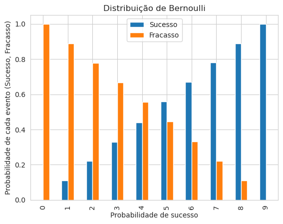

```python
# vendo como o aumento da probabilidade de sucesso muda a distribuição
lista_sucesso = []
lista_fracasso = []
lista2 = []
valores = 10

for i in list(np.linspace(0, 1, valores)):
    lista_sucesso.append(np.round(distribuicao_bernoulli(i)[0], 2))
    lista_fracasso.append(distribuicao_bernoulli(i)[1])
    lista2.append(i)

df_bernoulli = pd.DataFrame({'Sucesso': lista_sucesso, 'Fracasso': lista_fracasso})

with sns.axes_style("whitegrid"):
    plt.figure(figsize=(14, 5))
    df_bernoulli.plot(kind='bar')
    plt.xlabel('Probabilidade de sucesso')
    plt.ylabel('Probabilidade de cada evento (Sucesso, Fracasso)')
    plt.title('Distribuição de Bernoulli')
    plt.show()
```

## Distribuição Binomial

Vamos imaginar que repetimos o experimento que fizemos acima, na distribuição de Bernoulli, n vezes, sendo que essas repetições feitas são independentes uma das outras.

Vamos dizer que em vezes de escolher ao acaso apenas um funcionário que trabalhe no regime presencial, queremos 5 funcionários. Vamos listar as 5 tentativas:

1. Fracasso
2. Sucesso
3. Sucesso
4. Fracasso
5. Sucesso

Logo, a probabilidade dessa amostra será:

$$(1 - p)\cdot p \cdot p \cdot (1-p) \cdot p = p³ \cdot (1-p)²$$

Vamos considerar agora situação de uma moeda, qual a probabilidade de em 3 lançamentos, dar duas caras?

Podemos ter os seguintes resultados

- Sucesso, Sucesso, Fracasso (SSF)
- Sucesso, Fracasso, Sucesso (SFS)
- Fracasso, Sucesso, Sucesso (FSS)

Considerando a moeda honesta, temos a probabilidade de $\frac{1}{2}$ para dar cara. Sabendo que a ordem não importa, então temos:

$$P(SSF) = \frac{1}{2} \cdot \frac{1}{2} \cdot \frac{1}{2} = \frac{1}{8}$$$$P(SSF) = P(SFS) = P(FSS)$$$$P(A) = P(SSF) + P(SFS) + P(FSS)$$$$P(A) = \frac{3}{8}$$

Chamando novamente a probabilidade de sucesso de $p$, e probabilidade de fracasso de $1 - p = q$, então

$$P(SSF) = p \cdot p \cdot q = p² \cdot q$$

Substituindo para os outros valores, achamos que:

$$P(A) = 3p²q$$

Generalizando, temos:

$$P(A) = 3p^kq^{n-k}$$

Onde:

- n é o valor da amostra;
- k é o número de sucessos.

Nesse caso acima, formamos 3 possíveis sequências, mas e se jogássemos a moeda 30 vezes e buscássemos a probabilidade de dar 20 caras, como faríamos isso. Uma forma saber quantas sequências obteríamos é através da fórmula:

$${n \choose k} = \frac{n!}{k!\cdot(n-k)!}$$

Logo, a fórmula final é:

$$P(X = k) = {n \choose k}p^kq^{n-k}$$

Onde $k = 0, 1, ...., n$

a esperança matemática é:

$$E(X) = n\cdot p$$

variância

$$\text{Var}(X) = n\cdot p\cdot q$$

Definimos o experimento binomial ao experimento que:

1. que consiste em n ensaios de Bernoulli;
2. cujos ensaios são independentes; e
3. para qual a probabilidade de sucesso varia entre 0 e 1.

Quando uma variável aleatória tiver a distribuição de binomial, usaremos a seguinte notação:

$$X \sim b(n, p)$$

Com python temos:

```python
def fatorial(x):
    valor = 1
    for i in range(1, x+1):
        valor *= i
    return valor
```

```python
# número de sucessos = k
# tamanho da amostra = n
# probabilidade de sucesso = p
def distribuicao_binomial(numero_sucessos, tamanho_amostra, probabilidade_sucesso):
    possiveis_sequencias = (fatorial(tamanho_amostra)/(fatorial(numero_sucessos)
                                                       * fatorial(tamanho_amostra-numero_sucessos)))
    nao_sucessos = 1 - probabilidade_sucesso
    return (possiveis_sequencias * (probabilidade_sucesso**numero_sucessos)
            * (nao_sucessos **(tamanho_amostra-numero_sucessos)))
```

```python
distribuicao_binomial(2, 3, 0.5)
```

```
0.375
```

```python
# validando com scipy
stats.binom.pmf(2, 3, 0.5)
```

```
0.3750000000000001
```

```python
def distribuicao_binomial_problema(df, variavel, condicao_sucesso, numero_sucessos):
    tamanho_amostra = len(df)
    probabilidade_sucesso = len(df[df[variavel] == condicao_sucesso]) / tamanho_amostra
    possiveis_sequencias = Decimal((fatorial(tamanho_amostra)//(fatorial(numero_sucessos)
                                                       * fatorial(tamanho_amostra-numero_sucessos))))
    nao_sucessos = 1 - probabilidade_sucesso

    return float((possiveis_sequencias * Decimal((probabilidade_sucesso**numero_sucessos)
            * (nao_sucessos **(tamanho_amostra - numero_sucessos)))))
```

```python
(fatorial(3755) / fatorial(3730)) / fatorial(25)
```

```
1.3798435560850842e+64
```

```python
distribuicao_binomial_problema(df_salarios, 'tipo_trabalho', 'Presencial', 1923)
```

```
0.0
```

Nesse caso, temos uma distribuição grande, fazendo com que nossa distribuição dê a probabilidade 0. Vamos pegar 50 valores aleatórios do dataframe para testar.

```python
df_amostra = df_salarios.sample(n=50, random_state=42)
distribuicao_binomial_problema(df_amostra, 'tipo_trabalho', 'Presencial', 25)
```

```
0.058710477669917716
```

Agora temos que a probabilidade de pegar aleatoriamente 25 funcionários que trabalham no modo presencial é de 5,8%.

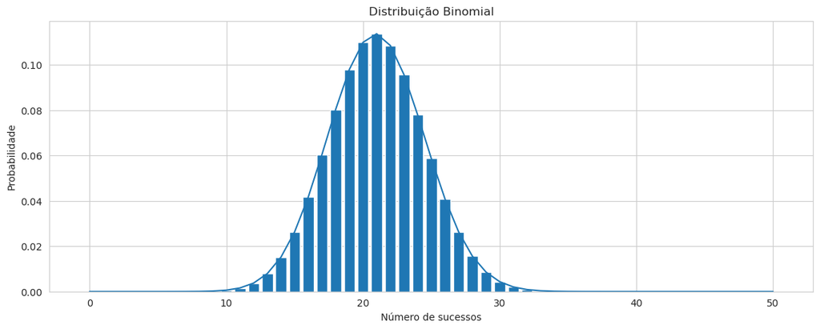

```python
lista = []
lista2 = []
for i in range(0, 51):
    lista.append(distribuicao_binomial_problema(df_amostra, 'tipo_trabalho', 'Presencial', i))
    lista2.append(i)

with sns.axes_style("whitegrid"):
    plt.figure(figsize=(14, 5))
    plt.bar(lista2, lista)
    plt.plot(lista2, lista)
    plt.xlabel('Número de sucessos')
    plt.ylabel('Probabilidade')
    plt.title('Distribuição Binomial')
    plt.show()
```

Temos no gráfico acima que o número de sucessos que nos dá a probabilidade mais alta é 21 casos, logo é mais provável retirarmos 21 funcionários que trabalham no modo presencial uma amostra aleatória de 50.

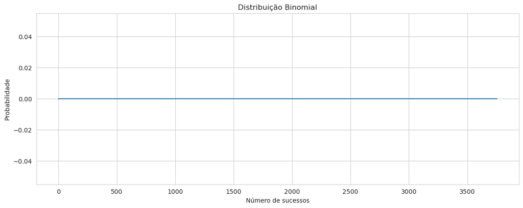

```python
lista = []
lista2 = []
for i in range(0, 3756):
    lista.append(distribuicao_binomial_problema(df_salarios, 'tipo_trabalho', 'Presencial', i))
    lista2.append(i)

with sns.axes_style("whitegrid"):
    plt.figure(figsize=(14, 5))
    plt.bar(lista2, lista)
    plt.plot(lista2, lista)
    plt.xlabel('Número de sucessos')
    plt.ylabel('Probabilidade')
    plt.title('Distribuição Binomial')
    plt.show()
```

Já no caso da amostra com todos os dados, temos que em todos os casos de número de sucesso, a probabilidade é 0.

## Distribuição Hipergeométrica

Essa distribuição é adequada quando consideramos extrações casuais feitas sem reposição de uma população dividida segundo dois atributos.

Sua fórmula é:

$$P(X=x) = {r \choose k}{N - r \choose n - k}/{N \choose n}$$$$= \frac{\frac{r!}{k!\cdot(r-k)!}\cdot\frac{(N-r)!}{(n-k)!\cdot[(N-r)- (n-k)]!}}{\frac{N!}{n!\cdot(N-n)!}}$$

Onde:

- N é a população total;
- r é a população do atributo desejado;
- n é o número extraído; e
- k é a quantidade de sucessos.

Vamos exemplificar, considerando que temos uma população de 100 pessoas, onde 30 são homens, vamos escolher 10 ao acaso. Qual a probabilidade de 5 dessas pessoas serem homens?

$$P(X=x) = {30 \choose 5}{100 - 30 \choose 10 - 5}/{100 \choose 10}$$$$= \frac{\frac{30!}{5!\cdot 25!}\cdot\frac{(70)!}{(5)!\cdot65!}}{\frac{100!}{10!\cdot(90)!}}$$$$= \frac{142506\cdot 12103014}{17310309460000} = 0,099$$

Logo, a probabilidade de 5 dessas pessoas tiradas ao acaso serem homens é de 9,9%. E a probabilidade de pelo menos uma dessas 5 pessoas ser mulher é:

$$1 - p = 0,9$$

a esperança matemática é:

$$E(X) = np $$

a variância é:

$$\text{Var}(X) = np(1 - p)\frac{N - n}{N - 1}$$

Quando uma variável aleatória tiver a distribuição de hipergeométrica, usaremos a seguinte notação:

$$X \sim hip(N, r, n)$$

no Python:

```python
def fatorial(x):
    valor = 1
    for i in range(1, x+1):
        valor *= i
    return valor
```

```python
def distribuicao_hipergeometrica(populacao_atributo_desejado, qtd_sucessos,
                                 populacao_total, numero_extraido_populacao):

    passo1 = (fatorial(populacao_atributo_desejado) /
              (fatorial(qtd_sucessos) *
               fatorial((populacao_atributo_desejado - qtd_sucessos))))

    passo2 = (fatorial((populacao_total-populacao_atributo_desejado)) /
             (fatorial((numero_extraido_populacao - qtd_sucessos)) *
              fatorial(((populacao_total-populacao_atributo_desejado) -
                        (numero_extraido_populacao - qtd_sucessos)))))

    passo3 = (fatorial(populacao_total) /
             (fatorial(numero_extraido_populacao) *
                                           fatorial((populacao_total -
                                                     numero_extraido_populacao))))

    return ((passo1 * passo2) / passo3)
```

```python
distribuicao_hipergeometrica(30, 5, 100, 10)
```

```
0.09963727785596206
```

```python
# validando com scipy
stats.hypergeom.pmf(5, 100, 30, 10)
```

```
0.09963727785596206
```

```python
lista = []
lista2 = []
for i in range(1, 21):
    lista.append(distribuicao_hipergeometrica(30, i, 100, 10))
    lista2.append(i)
```

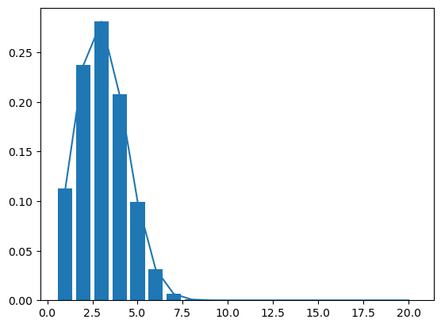

```python
plt.bar(lista2, lista)
plt.plot(lista2, lista)
plt.show()
```

```python
def distribuicao_hipergeometrica_problema(df, variavel, condicao_sucesso,
                                          qtd_sucessos, numero_extraido_populacao):
    populacao_total = len(df)

    populacao_atributo_desejado = len(df[df[variavel] == condicao_sucesso])

    passo1 = Decimal(fatorial(populacao_atributo_desejado) //
              (fatorial(qtd_sucessos) *
               fatorial((populacao_atributo_desejado - qtd_sucessos))))

    passo2 = Decimal(fatorial((populacao_total-populacao_atributo_desejado)) //
             (fatorial((numero_extraido_populacao - qtd_sucessos)) *
              fatorial(((populacao_total-populacao_atributo_desejado) -
                        (numero_extraido_populacao - qtd_sucessos)))))

    passo3 = Decimal(fatorial(populacao_total) //
             (fatorial(numero_extraido_populacao) *
                                           fatorial((populacao_total -
                                                     numero_extraido_populacao))))

    return float((passo1 * passo2) / passo3)
```

```python
distribuicao_hipergeometrica_problema(df_salarios, 'tipo_trabalho', 'Presencial', 25, 50)
```

```
0.11136100027569679
```

Logo, considerando uma amostra total de 3755, retirando 50 valores aleatórios, temos a probabilidade de 11% de retirar 25 pessoas que trabalham no padrão `presencial`.

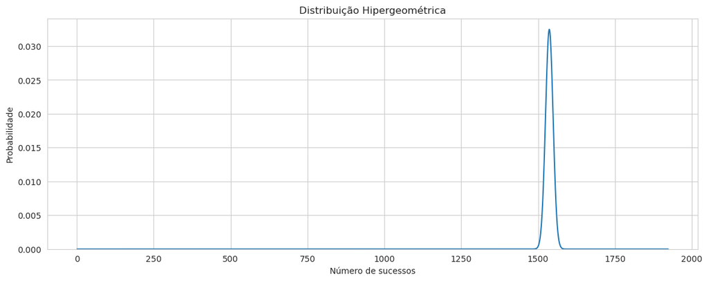

```python
lista = []
lista2 = []
for i in range(1, 1924):
    lista.append(distribuicao_hipergeometrica_problema(df_salarios, 'tipo_trabalho',
                                                       'Presencial', i, 3000))
    lista2.append(i)

with sns.axes_style("whitegrid"):
    plt.figure(figsize=(14, 5))
    plt.bar(lista2, lista)
    plt.plot(lista2, lista)
    plt.xlabel('Número de sucessos')
    plt.ylabel('Probabilidade')
    plt.title('Distribuição Hipergeométrica')
    plt.show()
```

## Distribuição de Poisson

A distribuição de Poisson é normalmente utilizada quando queremos contar eventos de certo tipo que ocorrem em um intervalo de tempo. Os eventos podem ser:

- acidentes automotivos em um dia;
- erros de digitação em uma hora;
- chegada de um cliente em um banco em algumas horas;
- Números de falhas em um computador em um minuto.

Sua fórmula é:

$$P(N = k) = \frac{e^{-\lambda} \lambda^{k}}{k!}$$

onde:

- $\lambda = np$
- $p$: é a probabilidade do evento acontecer;
- $n$: é o tamanho da população;
- $k$: número de sucessos

a esperança matemática é:

$$E(X) = \lambda$$

variância

$$\text{Var}(X) = \lambda$$

A distribuição de Poisson é aplicável quando o número de possíveis ocorrências discretas é muito maior do que o número médio de ocorrências em um determinado intervalo de tempo ou espaço. O número de possíveis ocorrências, muitas vezes não se sabe exatamente. Os resultados devem ocorrer de forma aleatória, ou seja, totalmente por acaso e da probabilidade de ocorrência não deve ser afetado pelos resultados ocorridos anteriormente, de modo que as ocorrências são independentes. Em muitos casos, embora possamos contar as ocorrências, como as quantidade de grãos de coloração diferente em um pacote de arroz, não podemos contar as não ocorrências correspondentes, a quantidade de grãos de coloração não diferente.

Quando uma variável aleatória tiver uma distribuição de Poisson, usaremos a seguinte notação:

$$X \sim Pois(\lambda)$$

Vamos ver um exemplo.

Qual a probabilidade de termos ações com valores de abertura acima 1 milhão de reais em toda a base de ações?

```python
def distribuicao_poisson(probabilidade, tamanho_populacao, numeros_sucessos):
    _lambda = probabilidade * tamanho_populacao
    return (np.exp(-_lambda) * _lambda**numeros_sucessos) / fatorial(numeros_sucessos)
```

```python
len(df_b3)
```

```
1883203
```

```python
acoes_acima = len(df_b3[df_b3['open'] > 1000000])
```

```python
probabilidade = acoes_acima / len(df_b3)
```

```python
distribuicao_poisson(probabilidade, len(df_b3), 1)
```

```
0.2706705664732254
```

```python
# validando com scipy
stats.poisson.pmf(1, 2)
```

```
0.2706705664732254
```

Logo, vemos que temos uma probabilidade de 27% de termos uma ação acima de 1 milhão de reais em todas as ações que temos.

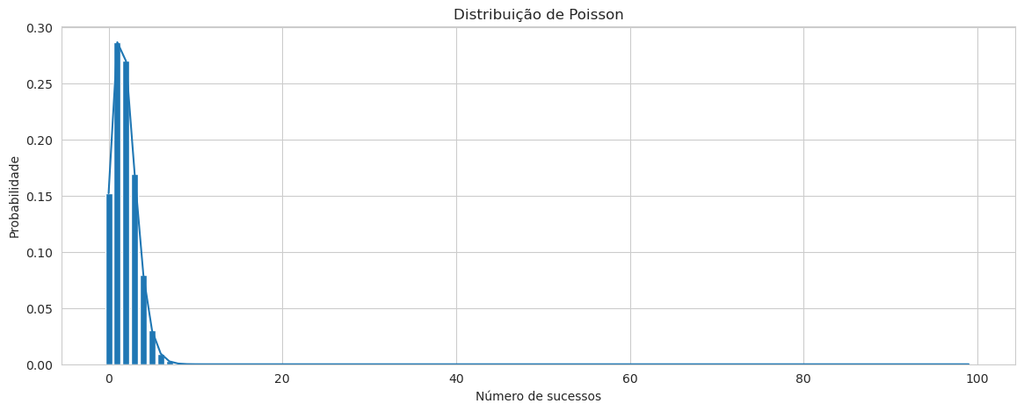

```python
lista = []
lista2 = []
valores = 10

for i in range(0, 100):
    lista.append(distribuicao_poisson(0.000001, len(df_b3), i))
    lista2.append(i)

with sns.axes_style("whitegrid"):
    plt.figure(figsize=(14, 5))
    plt.bar(lista2, lista)
    plt.plot(lista2, lista)
    plt.xlabel('Número de sucessos')
    plt.ylabel('Probabilidade')
    plt.title('Distribuição de Poisson')
    plt.show()
```

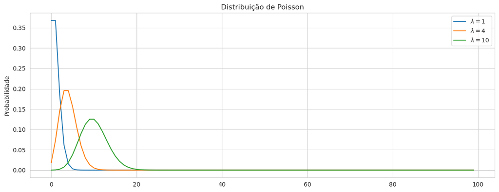

```python
lista_lambda1 = []
lista_lambda4 = []
lista_lambda10 = []
lista2 = []
valores = 10

for i in range(0, 100):
    lista_lambda1.append(distribuicao_poisson(5.31e-7, len(df_b3), i))
    lista_lambda4.append(distribuicao_poisson(4 * 5.31e-7, len(df_b3), i))
    lista_lambda10.append(distribuicao_poisson(10 * 5.31e-7, len(df_b3), i))
    lista2.append(i)

with sns.axes_style("whitegrid"):
    plt.figure(figsize=(14, 5))
    #plt.bar(lista2, lista)
    plt.plot(lista2, lista_lambda1, label='$\lambda = 1$')
    plt.plot(lista2, lista_lambda4, label='$\lambda = 4$')
    plt.plot(lista2, lista_lambda10, label='$\lambda = 10$')
    plt.ylabel('Probabilidade')
    plt.title('Distribuição de Poisson')
    plt.legend()
    plt.show()
```

# Referências

1. Morettin, P. A., Bussab, W. O. **Estatística Básica**, 6. ed. – São Paulo : Saraiva, 2010.
2. Bruce, P., Bruce, A., Gedeck, P. **Pratical Statistics for Data Scientists**, 2 ed. O'Reilly, 2020.

| [$\leftarrow$Ir para artigo anterior](https://fhfraga.github.io/pages/conceitos/estatistica/3_probabilidade.html) | [Voltar ao site](https://fhfraga.github.io/) | [Voltar à página de estatística](https://fhfraga.github.io/pages/conceitos/estatistica/) |
| --- | --- | --- |